# Systematic Macro Portfolio

Jason Dolatshahi, November 2026

| Window | May 2018 – Nov 2026 (n = 2,151 sessions) |
| --- | --- |
| Book Equity · Volatility | USD $10mm · 10% annualized |
| Sharpe · Sortino · Calmar (net of 3M T-Bills) | 2.21 · 3.40 · 2.71 |
| Sharpe · Sortino · Calmar (95% CI) | [1.71, 2.78] · [2.53, 4.45] · [1.70, 4.16] |
| Max Drawdown (10% vol) | 8.1% of equity (Oct–Nov 2026) |
| Benchmark Alpha, monthly (BTOP50 · 60/40) | 20.7% (t 9.2) · 21.4% (t 7.5) |
| Benchmark Beta, monthly (BTOP50 · 60/40) | 0.51 (R² 0.19) · 0.11 (R² 0.02) |
| Top Factor Betas (2026 median) | USD +0.31 · US Equities +0.26 · Gold +0.21 |

## Summary

- Systematic macro portfolio. Styles include trend, carry, relative value.
- Products span liquid ETFs and futures across asset classes.
- Walk-forward backtest, taker economics. Signal uses time `t-1` info for decision at time `t`.
- Trading decisions combine regime information with conditional mean and volatility forecasts.
- Results shown net of bid/ask costs, exchange fees, commissions, 3M T-Bills.
- Sharpe ratios annualized, from daily returns; monthly where a benchmark is monthly.
- Per-sleeve median holding periods range from under one session to 76 sessions.

## Backtest Performance

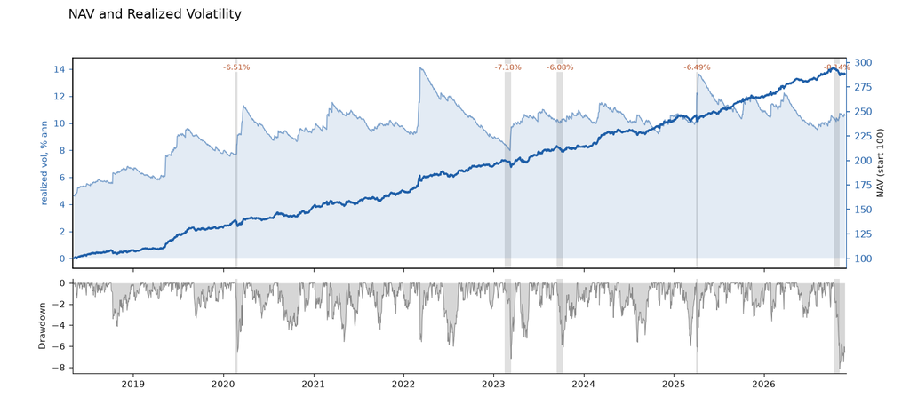

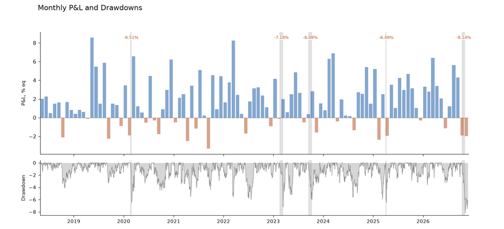

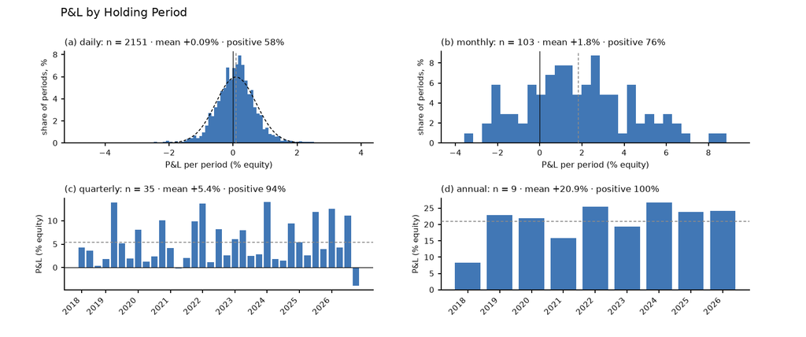

## Risk and Drawdown Profile

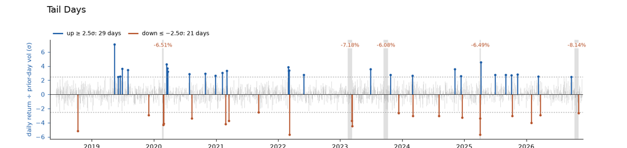

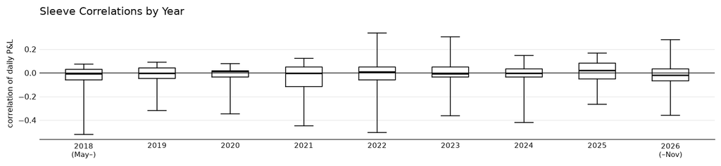

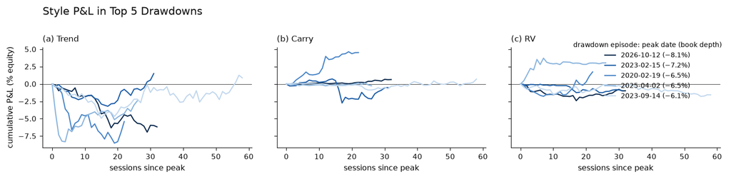

- Positive tail days slightly outnumber negative tail days (29 vs 21).
- Highest pairwise sleeve correlation across years is +0.34 (2022, FX trend × Rates RV)
- Lowest pairwise sleeve correlation is Core trend × FX trend in six of nine years (−0.32 to −0.50). FX sleeve’s USD long beta offsets USD short beta from core’s dollar-denominated assets.

## Benchmark Analysis

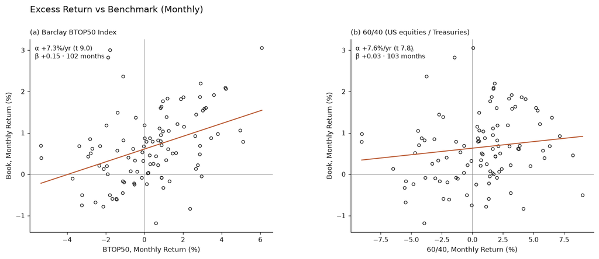

|  | Annualized Return over 3M T-Bills | Annualized Vol | Max Drawdown | Sharpe |
| --- | --- | --- | --- | --- |
| 60/40 | 6.5% | 12.2% | -27.3% | 0.53 |
| 60/40 + BTOP50 (80%/20%) | 5.9% | 9.7% | -20.4% | 0.61 |
| 60/40 + Book (80%/20%) | 9.7% | 10.1% | -17.9% | 0.96 |

Each row is the named sleeves’ P&L, scaled to 10% vol. Monthly regression of excess returns on the index’s excess returns; alpha annualized. t-statistics in parentheses, Newey–West (HAC, 3 lags).

| Sleeves held | Sharpe | Alpha vs BTOP50 (ann.) | Beta to BTOP50 | R² | Alpha vs 60/40 (ann.) | Beta to 60/40 |
| --- | --- | --- | --- | --- | --- | --- |
| Trend | 1.62 | 14.9% (6.5) | 0.53 (3.8) | 0.20 | 14.6% (4.9) | 0.25 (4.0) |
| Trend + RV | 2.15 | 19.9% (8.2) | 0.54 (5.0) | 0.23 | 20.7% (6.8) | 0.13 (1.6) |
| Trend + Carry | 1.81 | 17.1% (7.7) | 0.44 (3.2) | 0.14 | 16.7% (6.0) | 0.22 (3.8) |
| Combined Book | 2.21 | 20.7% (9.2) | 0.51 (4.5) | 0.19 | 21.4% (7.5) | 0.11 (1.5) |
| RV + Carry | 1.57 | 15.3% (4.0) | -0.01 (-0.1) | 0.00 | 17.2% (4.7) | -0.24 (-3.3) |

## Factor Exposure

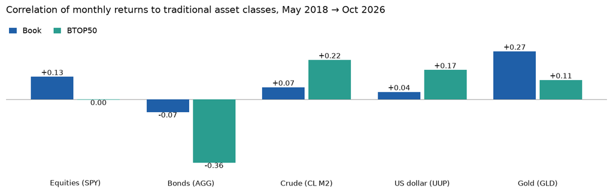

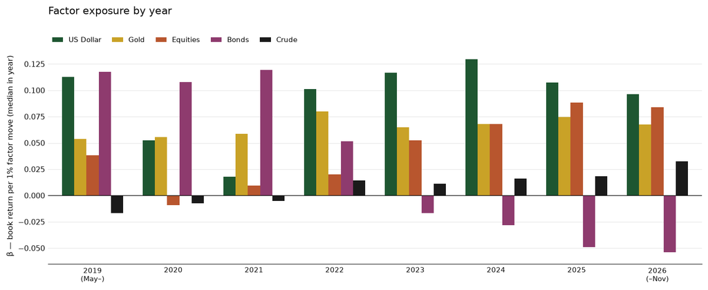

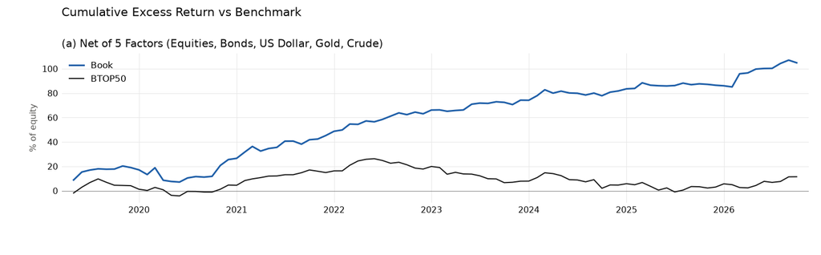

## Costs and Capacity

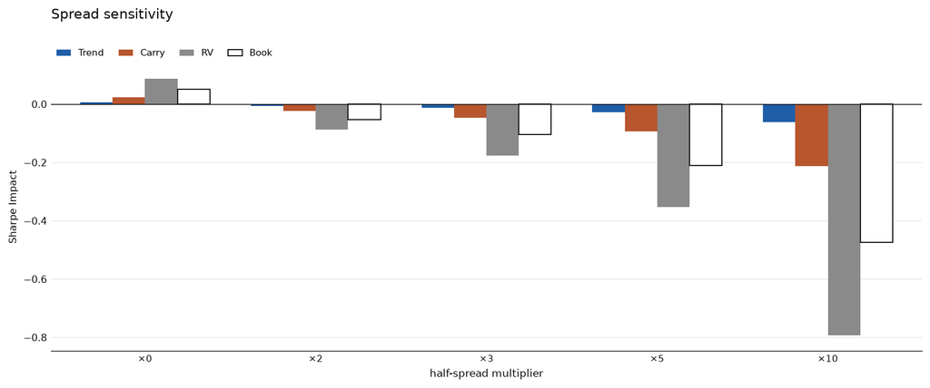

- Sharpe falls 0.05 at 2x assumed bid/ask, 0.47 at 10x assumed bid/ask.
- Square-root impact model costs 0.03–0.06 of Sharpe (can be mitigated via order pacing).
- ETF legs capped at 5% of closing auction volume.

## Portfolio Composition

| Style | Asset Class | Venues |
| --- | --- | --- |
| Trend | Core (broad basket of macro factors) | NYSE · CME |
| Trend | FX | CME |
| Carry | STIRs | CME |
| Carry | Energy | CME |
| Relative Value | Agriculture | CME |
| Relative Value | Rates | CME · Eurex |
| Relative Value | Energy | CME |
| Relative Value | Volatility (VIX futures) | Cboe (CFE) |

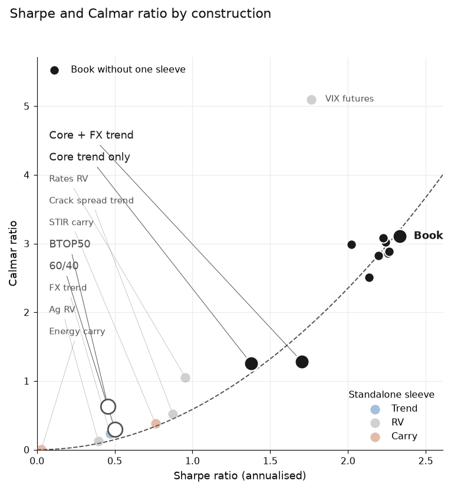

- All positions exchange-traded (no OTC).
- Each sleeve adds more Calmar than Sharpe (tail diversification accumulates disproportionately).

## Crisis Alpha

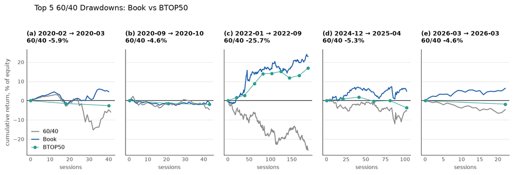

- Windows are the five deepest 60/40 drawdowns, month-end peak to trough. Book finishes above 60/40 in all five; BTOP50 is positive in one (2022).